# Credit Card Users Churn Prediction

# Building the model with Undersampled data

```python
models_undersampled = []  # Empty list to store all the models

# Appending models into the list
models_undersampled.append(("Bagging_Under", BaggingClassifier(random_state=1)))
models_undersampled.append(("Random_Forest_Under", RandomForestClassifier(random_state=1)))
models_undersampled.append(("GBM_Under", GradientBoostingClassifier(random_state=1)))
models_undersampled.append(("Adaboost_Under", AdaBoostClassifier(random_state=1)))
models_undersampled.append(("Xgboost_Under", XGBClassifier(random_state=1, eval_metric="logloss")))
models_undersampled.append(("DecissionTree_Under", DecisionTreeClassifier(random_state=1)))
models_undersampled.append(("Logistic_Regression_Under", LogisticRegression(random_state=1)))


results = []  # Empty list to store all model's CV scores
names = []  # Empty list to store name of the models


# loop through all models to get the mean cross validated score
print("\n" "Cross-Validation Performance:" "\n")

for name, model in models_undersampled:
    scoring = "recall"
    kfold = StratifiedKFold(
        n_splits=5, shuffle=True, random_state=1
    )  # Setting number of splits equal to 5
    cv_result = cross_val_score(
        estimator=model, X=X_train_un, y=y_train_un, scoring=scoring, cv=kfold
    )
    results.append(cv_result)
    names.append(name)
    print("{}: {}".format(name, cv_result.mean() * 100))

print("\n" "Validation Performance:" "\n")

for name, model in models_undersampled:
    model.fit(X_train_un, y_train_un)
    scores = recall_score(y_val, model.predict(X_val))
    print("{}: {}".format(name, scores))
```

```
Cross-Validation Performance:

Bagging_Under: 91.18890633176348
Random_Forest_Under: 92.72632129774988
GBM_Under: 93.95447409733124
Adaboost_Under: 93.24018838304553
Xgboost_Under: 94.26321297749868
DecissionTree_Under: 88.11459968602826
Logistic_Regression_Under: 77.7629513343799

Validation Performance:

Bagging_Under: 0.9294478527607362
Random_Forest_Under: 0.9294478527607362
GBM_Under: 0.9570552147239264
Adaboost_Under: 0.9601226993865031
Xgboost_Under: 0.9601226993865031
DecissionTree_Under: 0.901840490797546
Logistic_Regression_Under: 0.8312883435582822
```

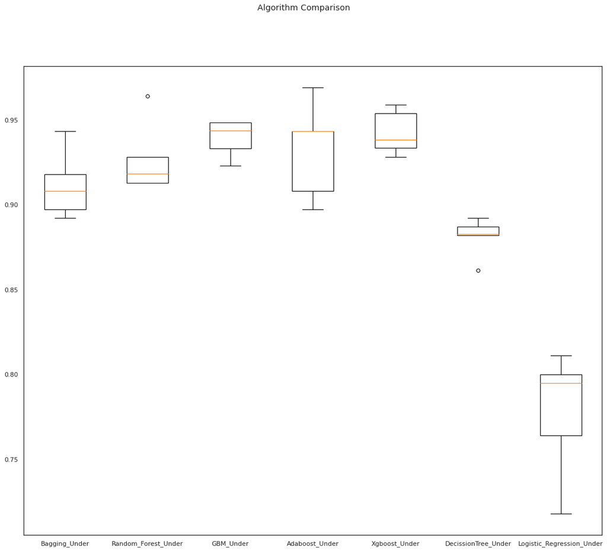

```python
# Plotting boxplots for CV scores of all models defined above
fig = plt.figure(figsize=(18, 15))

fig.suptitle("Algorithm Comparison")
ax = fig.add_subplot(111)

plt.boxplot(results)
ax.set_xticklabels(names)

plt.show()
```

# Hyperparameter tuning on original data using RandomizedSearchCV

## Tuning Adaboost

```python
%%time

# defining model
Model = AdaBoostClassifier(random_state=1)

# Parameter grid to pass in RandomSearchCV
param_grid = {
    "n_estimators": np.arange(10, 110, 10),
    "learning_rate": [0.1, 0.01, 0.2, 0.05, 1],
    "base_estimator": [
        DecisionTreeClassifier(max_depth=1, random_state=1),
        DecisionTreeClassifier(max_depth=2, random_state=1),
        DecisionTreeClassifier(max_depth=3, random_state=1),
    ],
}

# Type of scoring used to compare parameter combinations
scorer = metrics.make_scorer(metrics.recall_score)

#Calling RandomizedSearchCV
randomized_cv = RandomizedSearchCV(estimator=Model, param_distributions=param_grid, n_jobs = -1, n_iter=50, scoring=scorer, cv=5, random_state=1)

#Fitting parameters in RandomizedSearchCV
randomized_cv.fit(X_train,y_train)

print("Best parameters are {} with CV score={}:" .format(randomized_cv.best_params_,randomized_cv.best_score_))
```

```
Best parameters are {'n_estimators': 90, 'learning_rate': 1, 'base_estimator': DecisionTreeClassifier(max_depth=2, random_state=1)} with CV score=0.8698587127158556:
CPU times: user 4.04 s, sys: 304 ms, total: 4.34 s
Wall time: 1min 15s
```

```python
Ada_Tunned = AdaBoostClassifier(
    random_state=1,
    n_estimators=90,
    learning_rate=1,
    base_estimator=DecisionTreeClassifier(max_depth=2, random_state=1),
)
Ada_Tunned.fit(X_train, y_train)
```

```
AdaBoostClassifier(base_estimator=DecisionTreeClassifier(max_depth=2,
                                                         random_state=1),
                   learning_rate=1, n_estimators=90, random_state=1)
```

```python
# Checking model's performance on training set
Ada_Train = model_performance_classification_sklearn(Ada_Tunned, X_train, y_train)
Ada_Train
```

|  | Accuracy | Recall | Precision | F1 |
| --- | --- | --- | --- | --- |
| 0 | 0.996 | 0.985 | 0.991 | 0.988 |

```python
# Checking model's performance on validation set
Ada_Val = model_performance_classification_sklearn(Ada_Tunned, X_val, y_val)
Ada_Val
```

|  | Accuracy | Recall | Precision | F1 |
| --- | --- | --- | --- | --- |
| 0 | 0.965 | 0.865 | 0.916 | 0.890 |

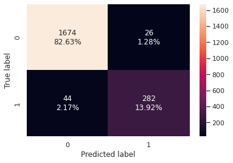

```python
# creating confusion matrix
confusion_matrix_sklearn(Ada_Tunned, X_val, y_val)
```

- AdaBoost model is also overfitting in terms of recall

## Tuning Xgboost

```python
# %%time

# defining model
Model = XGBClassifier(random_state=1,eval_metric='logloss')

#Parameter grid to pass in RandomSearchCV
param_grid={'n_estimators':np.arange(50,350,55),
            'max_depth':np.arange(1,5,1),
            'reg_lambda':[5,10],
            'scale_pos_weight':[0,1,2,5,10],
            'learning_rate':[0.01,0.1,0.2,0.05],
            'gamma':[0,1,3,5],
            'subsample':[0.7,0.8,0.9,1]
           }
from sklearn import metrics

# Type of scoring used to compare parameter combinations
scorer = metrics.make_scorer(metrics.recall_score)

#Calling RandomizedSearchCV
randomized_cv = RandomizedSearchCV(estimator=Model, param_distributions=param_grid, n_iter=50, n_jobs = -1, scoring=scorer, cv=5, random_state=1)

#Fitting parameters in RandomizedSearchCV
randomized_cv.fit(X_train,y_train)

print("Best parameters are {} with CV score={}:" .format(randomized_cv.best_params_,randomized_cv.best_score_))
```

```
Best parameters are {'subsample': 0.7, 'scale_pos_weight': 10, 'reg_lambda': 5, 'n_estimators': 50, 'max_depth': 2, 'learning_rate': 0.1, 'gamma': 1} with CV score=0.9682208267922554:
```

```python
Xgb_Tunned = XGBClassifier(
    random_state=1,
    eval_metric="logloss",
    subsample=0.7,
    scale_pos_weight=10,
    reg_lambda=5,
    n_estimators=50,
    max_depth=2,
    learning_rate=0.1,
    gamma=1,
)
Xgb_Tunned.fit(X_train, y_train)
```

```
XGBClassifier(eval_metric='logloss', gamma=1, max_depth=2, n_estimators=50,
              random_state=1, reg_lambda=5, scale_pos_weight=10, subsample=0.7)
```

```python
# Checking model's performance on training set
xgb_train = model_performance_classification_sklearn(Xgb_Tunned, X_train, y_train)
xgb_train
```

|  | Accuracy | Recall | Precision | F1 |
| --- | --- | --- | --- | --- |
| 0 | 0.848 | 0.980 | 0.514 | 0.674 |

```python
# Checking model's performance on validation set
xgb_val = model_performance_classification_sklearn(Xgb_Tunned, X_val, y_val)
xgb_val
```

|  | Accuracy | Recall | Precision | F1 |
| --- | --- | --- | --- | --- |
| 0 | 0.843 | 0.963 | 0.506 | 0.663 |

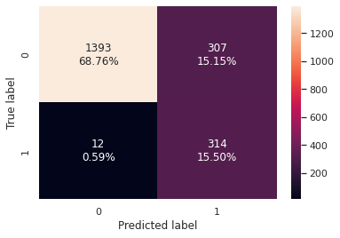

```python
# creating confusion matrix
confusion_matrix_sklearn(Xgb_Tunned, X_val, y_val)
```

- Model is giving us a generalized performance

## Tuning Gradient boosting classifier

```python
%%time

#defining model
Model = GradientBoostingClassifier(random_state=1)

#Parameter grid to pass in RandomSearchCV
param_grid = {
    "init": [AdaBoostClassifier(random_state=1),DecisionTreeClassifier(random_state=1)],
    "n_estimators": np.arange(75,150,25),
    "learning_rate": [0.1, 0.01, 0.2, 0.05, 1],
    "subsample":[0.5,0.7,1],
    "max_features":[0.5,0.7,1],
}

# Type of scoring used to compare parameter combinations
scorer = metrics.make_scorer(metrics.recall_score)

#Calling RandomizedSearchCV
randomized_cv = RandomizedSearchCV(estimator=Model, param_distributions=param_grid, n_iter=50, scoring=scorer, cv=5, random_state=1, n_jobs = -1)

#Fitting parameters in RandomizedSearchCV
randomized_cv.fit(X_train,y_train)

print("Best parameters are {} with CV score={}:" .format(randomized_cv.best_params_,randomized_cv.best_score_))
```

```
Best parameters are {'subsample': 0.7, 'n_estimators': 125, 'max_features': 0.7, 'learning_rate': 0.2, 'init': AdaBoostClassifier(random_state=1)} with CV score=0.8473050758765044:
CPU times: user 4.52 s, sys: 224 ms, total: 4.75 s
Wall time: 1min 19s
```

```python
GB_Tunned = GradientBoostingClassifier(
    random_state=1,
    subsample=0.7,
    n_estimators=125,
    max_features=0.7,
    learning_rate=0.2,
    init=AdaBoostClassifier(random_state=1),
)
GB_Tunned.fit(X_train, y_train)
```

```
GradientBoostingClassifier(init=AdaBoostClassifier(random_state=1),
                           learning_rate=0.2, max_features=0.7,
                           n_estimators=125, random_state=1, subsample=0.7)
```

```python
# Checking model's performance on training set
GB_Train = model_performance_classification_sklearn(GB_Tunned, X_train, y_train)
GB_Train
```

|  | Accuracy | Recall | Precision | F1 |
| --- | --- | --- | --- | --- |
| 0 | 0.989 | 0.953 | 0.980 | 0.966 |

```python
# Checking model's performance on validation set
GB_Val = model_performance_classification_sklearn(GB_Tunned, X_val, y_val)
GB_Val
```

|  | Accuracy | Recall | Precision | F1 |
| --- | --- | --- | --- | --- |
| 0 | 0.971 | 0.883 | 0.935 | 0.909 |

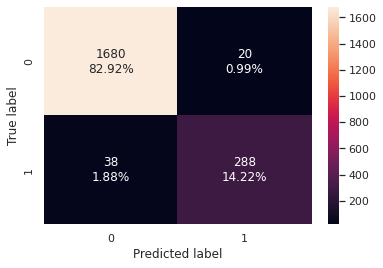

```python
# creating confusion matrix
confusion_matrix_sklearn(GB_Tunned, X_val, y_val)
```

- GradientBoost model is slightly overfitting in terms of recall score

# Hyperparameter tuning on oversampled data using RandomizedSearchCV

## Tuning Adaboost

```python
%%time

# defining model
Model = AdaBoostClassifier(random_state=1)

# Parameter grid to pass in RandomSearchCV
param_grid = {
    "n_estimators": np.arange(10, 110, 10),
    "learning_rate": [0.1, 0.01, 0.2, 0.05, 1],
    "base_estimator": [
        DecisionTreeClassifier(max_depth=1, random_state=1),
        DecisionTreeClassifier(max_depth=2, random_state=1),
        DecisionTreeClassifier(max_depth=3, random_state=1),
    ],
}

# Type of scoring used to compare parameter combinations
scorer = metrics.make_scorer(metrics.recall_score)

#Calling RandomizedSearchCV
randomized_cv = RandomizedSearchCV(estimator=Model, param_distributions=param_grid, n_jobs = -1, n_iter=50, scoring=scorer, cv=5, random_state=1)

#Fitting parameters in RandomizedSearchCV
randomized_cv.fit(X_train_over,y_train_over)

print("Best parameters are {} with CV score={}:" .format(randomized_cv.best_params_,randomized_cv.best_score_))
```

```
Best parameters are {'n_estimators': 90, 'learning_rate': 0.2, 'base_estimator': DecisionTreeClassifier(max_depth=2, random_state=1)} with CV score=0.929214531740076:
CPU times: user 5.3 s, sys: 264 ms, total: 5.56 s
Wall time: 1min 57s
```

```python
Ada_Tunned_Over = AdaBoostClassifier(
    random_state=1,
    n_estimators=90,
    learning_rate=0.1,
    base_estimator=DecisionTreeClassifier(max_depth=3, random_state=1),
)
Ada_Tunned_Over.fit(X_train_over, y_train_over)
```

```
AdaBoostClassifier(base_estimator=DecisionTreeClassifier(max_depth=3,
                                                         random_state=1),
                   learning_rate=0.1, n_estimators=90, random_state=1)
```

```python
# Checking model's performance on training set
Ada_Train_Over = model_performance_classification_sklearn(Ada_Tunned_Over, X_train_over, y_train_over)
Ada_Train_Over
```

|  | Accuracy | Recall | Precision | F1 |
| --- | --- | --- | --- | --- |
| 0 | 0.984 | 0.985 | 0.984 | 0.984 |

```python
# Checking model's performance on validation set
Ada_Val_Over = model_performance_classification_sklearn(Ada_Tunned_Over, X_val, y_val)
Ada_Val_Over
```

|  | Accuracy | Recall | Precision | F1 |
| --- | --- | --- | --- | --- |
| 0 | 0.968 | 0.905 | 0.897 | 0.901 |

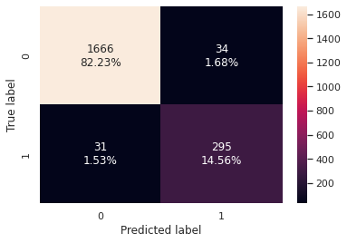

```python
# creating confusion matrix
confusion_matrix_sklearn(Ada_Tunned_Over, X_val, y_val)
```

- AdaBoost Model is overfitting in terms of recall

## Tuning Xgboost

```python
%%time

# defining model
Model = XGBClassifier(random_state=1,eval_metric='logloss')

#Parameter grid to pass in RandomSearchCV
param_grid={'n_estimators':np.arange(50,350,55),
            'max_depth':np.arange(1,5,1),
            'reg_lambda':[5,10],
            'scale_pos_weight':[0,1,2,5,10],
            'learning_rate':[0.01,0.1,0.2,0.05],
            'gamma':[0,1,3,5],
            'subsample':[0.7,0.8,0.9,1]
           }
from sklearn import metrics

# Type of scoring used to compare parameter combinations
scorer = metrics.make_scorer(metrics.recall_score)

#Calling RandomizedSearchCV
randomized_cv = RandomizedSearchCV(estimator=Model, param_distributions=param_grid, n_iter=50, n_jobs = -1, scoring=scorer, cv=5, random_state=1)

#Fitting parameters in RandomizedSearchCV
randomized_cv.fit(X_train_over,y_train_over)

print("Best parameters are {} with CV score={}:" .format(randomized_cv.best_params_,randomized_cv.best_score_))
```

```
Best parameters are {'subsample': 0.7, 'scale_pos_weight': 10, 'reg_lambda': 5, 'n_estimators': 50, 'max_depth': 2, 'learning_rate': 0.1, 'gamma': 1} with CV score=0.9974509803921568:
CPU times: user 3.61 s, sys: 293 ms, total: 3.9 s
Wall time: 2min 24s
```

```python
Xgb_Tunned_Over = XGBClassifier(
    random_state=1,
    eval_metric="logloss",
    subsample=0.7,
    scale_pos_weight=10,
    reg_lambda=5,
    max_depth=2,
    n_estimators=50,
    learning_rate=0.1,
    gamma=1,
)
Xgb_Tunned_Over.fit(X_train_over, y_train_over)
```

```
XGBClassifier(eval_metric='logloss', gamma=1, max_depth=2, n_estimators=50,
              random_state=1, reg_lambda=5, scale_pos_weight=10, subsample=0.7)
```

```python
# Checking model's performance on training set
xgb_train_over = model_performance_classification_sklearn(Xgb_Tunned_Over, X_train_over, y_train_over)
xgb_train_over
```

|  | Accuracy | Recall | Precision | F1 |
| --- | --- | --- | --- | --- |
| 0 | 0.813 | 1.000 | 0.728 | 0.843 |

```python
# Checking model's performance on validation set
xgb_val_over = model_performance_classification_sklearn(Xgb_Tunned_Over, X_val, y_val)
xgb_val_over
```

|  | Accuracy | Recall | Precision | F1 |
| --- | --- | --- | --- | --- |
| 0 | 0.692 | 0.988 | 0.342 | 0.508 |

## Tuning Gradient boosting classifier

```python
%%time

#defining model
Model = GradientBoostingClassifier(random_state=1)

#Parameter grid to pass in RandomSearchCV
param_grid = {
    "init": [AdaBoostClassifier(random_state=1),DecisionTreeClassifier(random_state=1)],
    "n_estimators": np.arange(75,150,25),
    "learning_rate": [0.1, 0.01, 0.2, 0.05, 1],
    "subsample":[0.5,0.7,1],
    "max_features":[0.5,0.7,1],
}

# Type of scoring used to compare parameter combinations
scorer = metrics.make_scorer(metrics.recall_score)

#Calling RandomizedSearchCV
randomized_cv = RandomizedSearchCV(estimator=Model, param_distributions=param_grid, n_iter=50, scoring=scorer, cv=5, random_state=1, n_jobs = -1)

#Fitting parameters in RandomizedSearchCV
randomized_cv.fit(X_train_over,y_train_over)

print("Best parameters are {} with CV score={}:" .format(randomized_cv.best_params_,randomized_cv.best_score_))
```

```
Best parameters are {'subsample': 1, 'n_estimators': 125, 'max_features': 0.7, 'learning_rate': 0.01, 'init': AdaBoostClassifier(random_state=1)} with CV score=0.9458750408897613:
CPU times: user 6.54 s, sys: 272 ms, total: 6.81 s
Wall time: 2min 9s
```

```python
GB_Tunned_Over = GradientBoostingClassifier(
    random_state=1,
    subsample=0.7,
    n_estimators=125,
    max_features=0.7,
    learning_rate=0.2,
    init=AdaBoostClassifier(random_state=1),
)
GB_Tunned_Over.fit(X_train_over, y_train_over)
```

```
GradientBoostingClassifier(init=AdaBoostClassifier(random_state=1),
                           learning_rate=0.2, max_features=0.7,
                           n_estimators=125, random_state=1, subsample=0.7)
```

```python
# Checking model's performance on training set
GB_Train_Over = model_performance_classification_sklearn(GB_Tunned_Over, X_train_over, y_train_over)
GB_Train_Over
```

|  | Accuracy | Recall | Precision | F1 |
| --- | --- | --- | --- | --- |
| 0 | 0.991 | 0.991 | 0.990 | 0.991 |

```python
# Checking model's performance on validation set
GB_Val_Over = model_performance_classification_sklearn(GB_Tunned_Over, X_val, y_val)
GB_Val_Over
```

|  | Accuracy | Recall | Precision | F1 |
| --- | --- | --- | --- | --- |
| 0 | 0.972 | 0.917 | 0.909 | 0.913 |

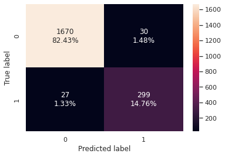

```python
# creating confusion matrix
confusion_matrix_sklearn(GB_Tunned_Over, X_val, y_val)
```

- Gradient boosting model is also overfitting a little in terms of recall

# Hyperparameter tuning on undersampled data using RandomizedSearchCV

## Tuning Adaboost

```python
%%time

# defining model
Model = AdaBoostClassifier(random_state=1)

# Parameter grid to pass in RandomSearchCV
param_grid = {
    "n_estimators": np.arange(10, 110, 10),
    "learning_rate": [0.1, 0.01, 0.2, 0.05, 1],
    "base_estimator": [
        DecisionTreeClassifier(max_depth=1, random_state=1),
        DecisionTreeClassifier(max_depth=2, random_state=1),
        DecisionTreeClassifier(max_depth=3, random_state=1),
    ],
}

# Type of scoring used to compare parameter combinations
scorer = metrics.make_scorer(metrics.recall_score)

#Calling RandomizedSearchCV
randomized_cv = RandomizedSearchCV(estimator=Model, param_distributions=param_grid, n_jobs = -1, n_iter=50, scoring=scorer, cv=5, random_state=1)

#Fitting parameters in RandomizedSearchCV
randomized_cv.fit(X_train_un,y_train_un)

print("Best parameters are {} with CV score={}:" .format(randomized_cv.best_params_,randomized_cv.best_score_))
```

```
Best parameters are {'n_estimators': 70, 'learning_rate': 0.1, 'base_estimator': DecisionTreeClassifier(max_depth=2, random_state=1)} with CV score=0.9436630036630037:
CPU times: user 2.3 s, sys: 100 ms, total: 2.4 s
Wall time: 30.4 s
```

```python
Ada_Tunned_Under = AdaBoostClassifier(
    random_state=1,
    n_estimators=90,
    learning_rate=0.2,
    base_estimator=DecisionTreeClassifier(max_depth=3, random_state=1),
)
Ada_Tunned_Under.fit(X_train_un, y_train_un)
```

```
AdaBoostClassifier(base_estimator=DecisionTreeClassifier(max_depth=3,
                                                         random_state=1),
                   learning_rate=0.2, n_estimators=90, random_state=1)
```

```python
# Checking model's performance on training set
Ada_Train_Under = model_performance_classification_sklearn(Ada_Tunned_Under, X_train_un, y_train_un)
Ada_Train_Under
```

|  | Accuracy | Recall | Precision | F1 |
| --- | --- | --- | --- | --- |
| 0 | 1.000 | 1.000 | 1.000 | 1.000 |

```python
# Checking model's performance on validation set
Ada_Val_Under = model_performance_classification_sklearn(Ada_Tunned_Under, X_val, y_val)
Ada_Val_Under
```

|  | Accuracy | Recall | Precision | F1 |
| --- | --- | --- | --- | --- |
| 0 | 0.930 | 0.957 | 0.709 | 0.815 |

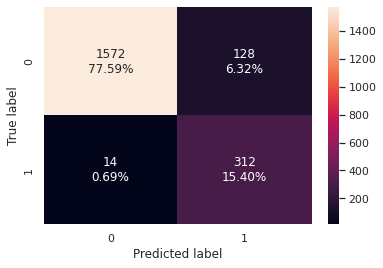

```python
# creating confusion matrix
confusion_matrix_sklearn(Ada_Tunned_Under, X_val, y_val)
```

- AdaBoost Model is overfitting in terms of recall

## Tuning Xgboost

```python
%%time

# defining model
Model = XGBClassifier(random_state=1,eval_metric='logloss')

#Parameter grid to pass in RandomSearchCV
param_grid={'n_estimators':np.arange(50,350,55),
            'max_depth':np.arange(1,5,1),
            'reg_lambda':[5,10],
            'scale_pos_weight':[0,1,2,5,10],
            'learning_rate':[0.01,0.1,0.2,0.05],
            'gamma':[0,1,3,5],
            'subsample':[0.7,0.8,0.9,1]
           }
from sklearn import metrics

# Type of scoring used to compare parameter combinations
scorer = metrics.make_scorer(metrics.recall_score)

#Calling RandomizedSearchCV
randomized_cv = RandomizedSearchCV(estimator=Model, param_distributions=param_grid, n_iter=50, n_jobs = -1, scoring=scorer, cv=5, random_state=1)

#Fitting parameters in RandomizedSearchCV
randomized_cv.fit(X_train_un,y_train_un)

print("Best parameters are {} with CV score={}:" .format(randomized_cv.best_params_,randomized_cv.best_score_))
```

```
Best parameters are {'subsample': 0.7, 'scale_pos_weight': 10, 'reg_lambda': 5, 'n_estimators': 50, 'max_depth': 2, 'learning_rate': 0.1, 'gamma': 1} with CV score=0.994887493458922:
CPU times: user 1.97 s, sys: 100 ms, total: 2.07 s
Wall time: 29.8 s
```

```python
Xgb_Tunned_Under = XGBClassifier(
    random_state=1,
    eval_metric="logloss",
    subsample=0.7,
    scale_pos_weight=10,
    reg_lambda=5,
    n_estimators=50,
    max_depth=2,
    learning_rate=0.1,
    gamma=1,
)
Xgb_Tunned_Under.fit(X_train_un, y_train_un)
```

```
XGBClassifier(eval_metric='logloss', gamma=1, max_depth=2, n_estimators=50,
              random_state=1, reg_lambda=5, scale_pos_weight=10, subsample=0.7)
```

```python
# Checking model's performance on training set
xgb_train_under = model_performance_classification_sklearn(Xgb_Tunned_Under, X_train, y_train)
xgb_train_under
```

|  | Accuracy | Recall | Precision | F1 |
| --- | --- | --- | --- | --- |
| 0 | 0.659 | 1.000 | 0.320 | 0.485 |

```python
# Checking model's performance on validation set
xgb_val_under = model_performance_classification_sklearn(Xgb_Tunned_Under, X_val, y_val)
xgb_val_under
```

|  | Accuracy | Recall | Precision | F1 |
| --- | --- | --- | --- | --- |
| 0 | 0.664 | 0.997 | 0.323 | 0.488 |

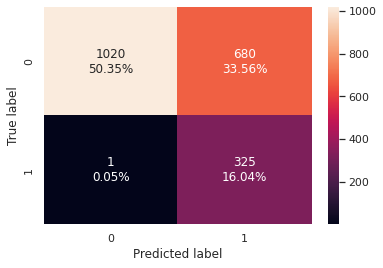

```python
# creating confusion matrix
confusion_matrix_sklearn(Xgb_Tunned_Under, X_val, y_val)
```

- XGBoost Model is giving a generalized performance

## Tuning Gradient boosting classifier

```python
%%time

#defining model
Model = GradientBoostingClassifier(random_state=1)

#Parameter grid to pass in RandomSearchCV
param_grid = {
    "init": [AdaBoostClassifier(random_state=1),DecisionTreeClassifier(random_state=1)],
    "n_estimators": np.arange(75,150,25),
    "learning_rate": [0.1, 0.01, 0.2, 0.05, 1],
    "subsample":[0.5,0.7,1],
    "max_features":[0.5,0.7,1],
}

# Type of scoring used to compare parameter combinations
scorer = metrics.make_scorer(metrics.recall_score)

#Calling RandomizedSearchCV
randomized_cv = RandomizedSearchCV(estimator=Model, param_distributions=param_grid, n_iter=50, scoring=scorer, cv=5, random_state=1, n_jobs = -1)

#Fitting parameters in RandomizedSearchCV
randomized_cv.fit(X_train_un,y_train_un)

print("Best parameters are {} with CV score={}:" .format(randomized_cv.best_params_,randomized_cv.best_score_))
```

```
Best parameters are {'subsample': 0.7, 'n_estimators': 100, 'max_features': 0.5, 'learning_rate': 0.1, 'init': AdaBoostClassifier(random_state=1)} with CV score=0.95287284144427:
CPU times: user 2.63 s, sys: 87.6 ms, total: 2.71 s
Wall time: 34.2 s
```

```python
GB_Tunned_Under = GradientBoostingClassifier(
    random_state=1,
    subsample=0.7,
    n_estimators=125,
    max_features=0.7,
    learning_rate=0.2,
    init=AdaBoostClassifier(random_state=1),
)
GB_Tunned_Under.fit(X_train_un, y_train_un)
```

```
GradientBoostingClassifier(init=AdaBoostClassifier(random_state=1),
                           learning_rate=0.2, max_features=0.7,
                           n_estimators=125, random_state=1, subsample=0.7)
```

```python
# Checking model's performance on training set
GB_Train_Under = model_performance_classification_sklearn(GB_Tunned_Under, X_train_un, y_train_un)
GB_Train_Under
```

|  | Accuracy | Recall | Precision | F1 |
| --- | --- | --- | --- | --- |
| 0 | 0.998 | 1.000 | 0.996 | 0.998 |

```python
# Checking model's performance on validation set
GB_Val_Under = model_performance_classification_sklearn(GB_Tunned_Under, X_val, y_val)
GB_Val_Under
```

|  | Accuracy | Recall | Precision | F1 |
| --- | --- | --- | --- | --- |
| 0 | 0.943 | 0.960 | 0.754 | 0.845 |

# Comparing all models

```python
# training performance comparison

models_train_comp_df = pd.concat(
    [
        Ada_Train.T,
        Ada_Val.T,
        Ada_Train_Over.T,
        Ada_Val_Over.T,
        Ada_Train_Under.T,
        Ada_Val_Under.T,
        GB_Train.T,
        GB_Val.T,
        GB_Train_Over.T,
        GB_Val_Over.T,
        GB_Train_Under.T,
        GB_Val_Under.T,
        xgb_train.T,
        xgb_val.T,
        xgb_train_over.T,
        xgb_val_over.T,
        xgb_train_under.T,
        xgb_val_under.T,
    ],
    axis=1,
)
models_train_comp_df.columns = [
    "AdaBoost trained original",
    "AdaBoost Validation original",
    "AdaBoost trained on oversample",
    "AdaBoost validation on oversample",
    "AdaBoost trained on undersample",
    "AdaBoost validation on undersample",
    "GradientBoost trained original",
    "GradientBoost validation original",
    "GradientBoost trained on oversample",
    "GradientBoost validation on oversample",
    "GradientBoost trained on undersample",
    "GradientBoost validation on undersample",
    "XGBoost trained original",
    "XGBoost validation original",
    "XGBoost trained on oversample",
    "XGBoost validation on oversample",
    "XGBoost trained on undersample",
    "XGBoost validation on undersample",
]
print("Training performance comparison:")
models_train_comp_df.T
```

```
Training performance comparison:
```

|  | Accuracy | Recall | Precision | F1 |
| --- | --- | --- | --- | --- |
| AdaBoost trained original | 0.996 | 0.985 | 0.991 | 0.988 |
| AdaBoost Validation original | 0.965 | 0.865 | 0.916 | 0.890 |
| AdaBoost trained on oversample | 0.984 | 0.985 | 0.984 | 0.984 |
| AdaBoost validation on oversample | 0.968 | 0.905 | 0.897 | 0.901 |
| AdaBoost trained on undersample | 1.000 | 1.000 | 1.000 | 1.000 |
| AdaBoost validation on undersample | 0.930 | 0.957 | 0.709 | 0.815 |
| GradientBoost trained original | 0.989 | 0.953 | 0.980 | 0.966 |
| GradientBoost validation original | 0.971 | 0.883 | 0.935 | 0.909 |
| GradientBoost trained on oversample | 0.991 | 0.991 | 0.990 | 0.991 |
| GradientBoost validation on oversample | 0.972 | 0.917 | 0.909 | 0.913 |
| GradientBoost trained on undersample | 0.998 | 1.000 | 0.996 | 0.998 |
| GradientBoost validation on undersample | 0.943 | 0.960 | 0.754 | 0.845 |
| XGBoost trained original | 0.848 | 0.980 | 0.514 | 0.674 |
| XGBoost validation original | 0.843 | 0.963 | 0.506 | 0.663 |
| XGBoost trained on oversample | 0.813 | 1.000 | 0.728 | 0.843 |
| XGBoost validation on oversample | 0.692 | 0.988 | 0.342 | 0.508 |
| XGBoost trained on undersample | 0.659 | 1.000 | 0.320 | 0.485 |
| XGBoost validation on undersample | 0.664 | 0.997 | 0.323 | 0.488 |

- Xgboost trained using original data has the best generalised performance
- Adaboost with undersampled data is performing the best but overfit for Precision and F1 score
- Gradient boosting with undersampled data is also performing good but it is also overfit for precision and f1 score
- Adaboost trained with undersampled data is also performing good.
- **I am considering XGBoost model built with original data set for productionizing using pipelince, since it is giving the best performance.**

#### Performance on the test set

```python
# Calculating different metrics on the test set
xgboost_grid_test = model_performance_classification_sklearn(Xgb_Tunned, X_test, y_test)
print("Test performance:")
xgboost_grid_test
```

```
Test performance:
```

|  | Accuracy | Recall | Precision | F1 |
| --- | --- | --- | --- | --- |
| 0 | 0.849 | 0.991 | 0.516 | 0.679 |

- The performance on test data is generalised

```python
Xgb_Tunned.feature_importances_
```

```
array([0.01835774, 0.        , 0.04256543, 0.08092487, 0.07039756,
       0.0699276 , 0.00675014, 0.14252566, 0.        , 0.07259118,
       0.11556888, 0.23854594, 0.07354158, 0.06830346, 0.        ,
       0.        , 0.        , 0.        , 0.        , 0.        ,
       0.        , 0.        , 0.        , 0.        , 0.        ,
       0.        , 0.        , 0.        , 0.        , 0.        ,
       0.        , 0.        , 0.        , 0.        ], dtype=float32)
```

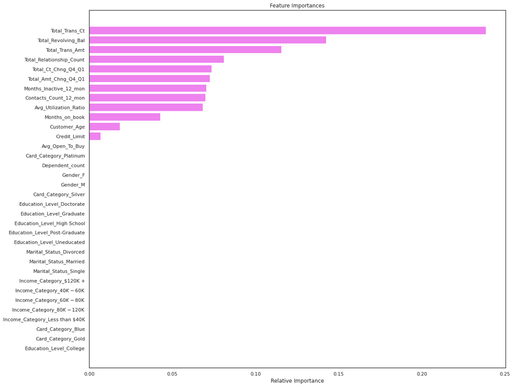

```python
feature_names = X_train_un.columns
importances = Xgb_Tunned.feature_importances_
indices = np.argsort(importances)

plt.figure(figsize=(17, 15))
plt.title("Feature Importances")
plt.barh(range(len(indices)), importances[indices], color="violet", align="center")
plt.yticks(range(len(indices)), [feature_names[i] for i in indices])
plt.xlabel("Relative Importance")
plt.show()
```

- `Total_Trans_Ct, Total_Revolving_Bal, Total_Trans_Amt, total_Relationship_Count` seem to be most top 4 important features.
- `Total_Ct_Chng_Q4_Q1, Total_Amt_Chng_Q4_Q1, Months_Inactive_12_mon, Contacts_Count_12_mon, Avg_Utilization_Ratio` still fall under top 10 important features
- `Months_on_book, Customer_Age,Credit_Limit` seem to have importance falling next in line.
- Rest of the features doesn't seem to be very important.

## Pipelines for productionizing the model

- Now, we have a final model. let's use pipelines to put the model into production